# Atividade Computacional 1

Daniel de Amaral da Silva

March 20, 2019

**Setando a semente**

```r
set.seed(22022019)
```

**Pacotes necessários**

```r
library(kableExtra)
library(dplyr)
library(TeachingSampling)
library(ggplot2)
```

**Dataset Lucy**

```r
data(Lucy)
attach(Lucy)

head(Lucy) %>%
  kable('html') %>%
  kable_styling(bootstrap_options = c("striped", "hover", "condensed"))
```

| ID | Ubication | Level | Zone | Income | Employees | Taxes | SPAM |
| --- | --- | --- | --- | --- | --- | --- | --- |
| AB001 | c1k1 | Small | A | 281 | 41 | 3 | no |
| AB002 | c1k2 | Small | A | 329 | 19 | 4 | yes |
| AB003 | c1k3 | Small | A | 405 | 68 | 7 | no |
| AB004 | c1k4 | Small | A | 360 | 89 | 5 | no |
| AB005 | c1k5 | Small | A | 391 | 91 | 7 | yes |
| AB006 | c1k6 | Small | A | 296 | 89 | 3 | no |

**Atividades**

**1.** Fazer uma análise descritiva da variável Income (Renda). Sugestão: é muito importante pesquisar (estudar) a base de dados Lucy antes de fazer a análise descritiva.

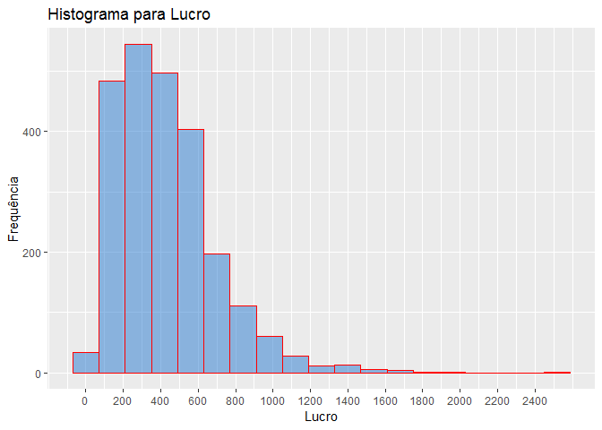

```r
Lucy %>% ggplot(aes(Lucy$Income)) +
  geom_histogram(binwidth = 140,
                  col="red",
                  fill='#2879d0',
                  alpha = .5) +
  scale_x_continuous(breaks = seq(0, 2550, by = 200))+
  labs(title="Histograma para Lucro") +
  ylab('Frequência') +
  xlab('Lucro')
```

```r
s = summary(Lucy$Income)
estatisticas = as.vector(s)
as.data.frame(estatisticas, names(s)) %>%
  kable('html') %>%
  kable_styling(bootstrap_options = c("striped", "hover", "condensed"))
```

|  | estatisticas |
| --- | --- |
| Min. | 1.0000 |
| 1st Qu. | 230.0000 |
| Median | 390.0000 |
| Mean | 432.0605 |
| 3rd Qu. | 576.0000 |
| Max. | 2510.0000 |

> Nota-se a presença de valores atípicos ao analisar o intervalo entre o 3º Quartil e o valor Máximo

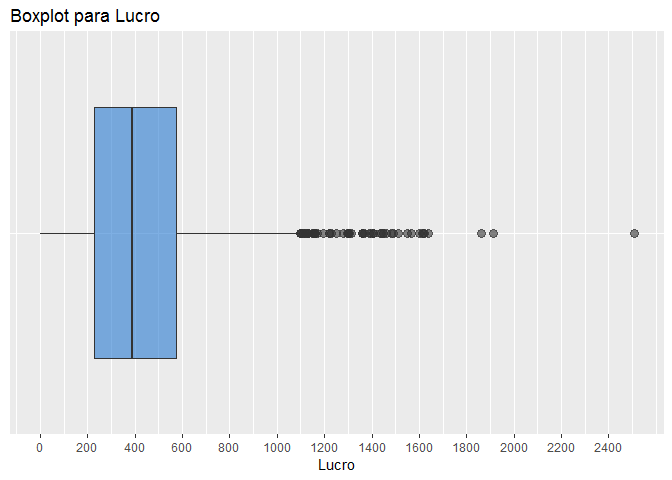

```r
Lucy %>% ggplot(aes(y = Lucy$Income, x = 'Income')) +
  geom_boxplot(outlier.size = 3, fill='#2879d0', alpha = .6) +
  theme(axis.title.y=element_blank(),
        axis.text.y=element_blank(),
        axis.ticks.y=element_blank()) +
  scale_y_continuous(breaks = seq(0, 2550, by = 200))+
  labs(title = 'Boxplot para Lucro') +
  ylab('Lucro')+
  coord_flip()
```

> Fica evidente com a visualização do histograma que 50% das empresas tiveram lucros entre 230 e 576 e de que menos de 25% das empresas possuiram um padrão de lucro acima de 1000. Apesar de termos constatados valores atípicos, tal fato só reforça a idéia de que há empresas que cresceram bastante em comparação ao ano em questão, em contraste com isto menos de 25% das empresas estudadas tiveram lucro de menos que 230. Contudo, nenhuma teve lucro negativo (prejuizo).

**2.** Obter uma amostra mediante uma amostragem de Bernoulli usando $\pi = 0,2$. Calcular o $\pi$-estimador de total e sua respectiva variância estimada para a variável Income. (Analisar os resultados)

```r
# Amostragem Bernoulli(2396, 0.2)
pi = 0.2
N = dim(Lucy)[1]
am_ber_ik = S.BE(N, pi)
am_ber = Lucy[am_ber_ik, ]
dim(am_ber)
```

```
## [1] 480   8
```

```r
# Pi-estimador
pi_est = E.BE(am_ber['Income'], pi)
pi_est %>%
  kable('html') %>%
  kable_styling(bootstrap_options = c("striped", "hover", "condensed"))
```

|  | N | Income |
| --- | --- | --- |
| Estimation | 2400.000000 | 1.034300e+06 |
| Standard Error | 97.979590 | 4.922418e+04 |
| CVE | 4.082483 | 4.759178e+00 |
| DEFF | Inf | 3.777734e+00 |

> Ao a analisar os resultados notamos que as Estimações do tamanho amostral e do Total da variável Income se aproximam do valor real, isto é evidenciado pelo Erro padrão e pelo Coeficiente de Variação estimado, que nos mostra um erro de tolerância de 4.75% e nos indica um sinal de homogeneidade da população. Além disso, a razão de variâncias (DEFF) é igual a aproximadamente 3.77, isso nos indica que a variância da amostragem de Bernoulli neste caso possui aproximadamente uma variância 3.77 vezes maior que a de uma amostragem simples sem reposição.

**3.** O tamanho amostral obtido no item anterior é semelhante ou muito diferente do esperado? Justificar sua resposta

> É semelhante sim, o tamanho esperado numa amostragem de Bernoulli tem distribuição Binomial e sua esperança é dada por:

$$\mathbb{E}[n_s] = N\pi, \text{ dado } N = 2396 \text{ e } \pi = 0.2$$
$$\mathbb{E}[n_s] = 479.2$$

> No experimento do item anterior obtivemos o tamanho amostral de:

```
## [1] 480
```

> Podemos então notar a proximidade do tamanho esperado 479.2 e o observado 480.

**4.** Obter uma amostra de tamanho $480$ mediante uma amostragem simples sem reposição. Calcular o $\pi$-estimador de total e sua respectiva variância estimada para a variável Income. (Analisar os resultados)

```r
# Amostragem Aleatória Simples
n = 480
am_si_ik = S.SI(N, n)
am_si = Lucy[am_si_ik, ]
dim(am_si)
```

```
## [1] 480   8
```

```r
# Pi-estimador
pi_est2 = E.SI(N, n, am_si['Income'])
pi_est2 %>%
  kable('html') %>%
  kable_styling(bootstrap_options = c("striped", "hover", "condensed"))
```

|  | N | Income |
| --- | --- | --- |
| Estimation | 2396 | 1.033799e+06 |
| Standard Error | 0 | 2.422836e+04 |
| CVE | 0 | 2.343624e+00 |
| DEFF | NaN | 1.000000e+00 |

> Ao a analisar os resultados notamos que as Estimações do tamanho amostral e do Total da variável Income se aproximam do valor real, isto é evidenciado pelo Erro padrão e pelo Coeficiente de Variação estimado, que nos mostra um erro de tolerância de 2.34% e nos indica um sinal de homogeneidade da população. Além disso, a razão de variâncias (DEFF) se iguala à 1, pois foi calculada a razão de 2 amostragens simples sem reposição.

**5.** Comparar os resultados obtidos nas questões 2 e 4.

> Ao comparar os resultados obtidos nos items 2 e 4, notamos um mesmo tamanho amostral. Em relação à estimação do total notamos que a amostragem simples sem reposição neste caso é mais precisa de que a amostragem de Bernoulli devido ao baixo desvio padrão e consequentemente neste caso o Coeficiente de variação estimado da amostragem de Bernoulli ser aproximadamente o dobro da amostragem simples sem reposição. Contudo, apesar da amostragem simples sem reposição ser mais precisa de que a amostragem de Bernoulli, a amostragem de Bernoulli é mais exata do que a amostragem simples sem reposição, pois se aproxima mais do valor real do total da variável Income.

**6.** A variável Level tem três categorias (Big, Medium e Small). Suponha que cada categoria é uma população diferente. Obtenha uma amostra aleatória simples sem reposição para cada categoria do 20% do tamanho de cada população. Calcular o $\pi$-estimador e sua respectiva variância para cada categoria. Com estes resultados é possível obter uma estimativa para o total de população em geral e sua variância estimada? Caso que a resposta for afirmativa, quais são os valores correspondentes? Precisa fazer algumas suposições? (Justificar sua resposta).

```r
# Small
Small = Lucy[Lucy$Level == 'Small',]
am_Small_ik = S.SI(dim(Small)[1], round(dim(Small)[1]*0.2))
am_Small = Small[am_Small_ik, ]
# Pi-estimador
pi_est3 = E.SI(dim(Small)[1], dim(am_Small)[1], am_Small[c('Income','Employees','Taxes')])
pi_est3 %>%
  kable('html') %>%
  kable_styling(bootstrap_options = c("striped", "hover", "condensed"))
```

|  | N | Income | Employees | Taxes |
| --- | --- | --- | --- | --- |
| Estimation | 1576 | 4.476440e+05 | 85264.101587 | 6238.958730 |
| Standard Error | 0 | 9.903975e+03 | 1995.082229 | 256.008920 |
| CVE | 0 | 2.212467e+00 | 2.339885 | 4.103392 |
| DEFF | NaN | 1.000000e+00 | 1.000000 | 1.000000 |

```r
# Medium
Medium = Lucy[Lucy$Level == 'Medium',]
am_Medium_ik = S.SI(dim(Medium)[1], round(dim(Medium)[1]*0.2))
am_Medium = Medium[am_Medium_ik, ]
# Pi-estimador
pi_est4 = E.SI(dim(Medium)[1], dim(am_Medium)[1], am_Medium[c('Income','Employees','Taxes')])
pi_est4 %>%
  kable('html') %>%
  kable_styling(bootstrap_options = c("striped", "hover", "condensed"))
```

|  | N | Income | Employees | Taxes |
| --- | --- | --- | --- | --- |
| Estimation | 737 | 5.054968e+05 | 60594.435374 | 17592.741497 |
| Standard Error | 0 | 7.052571e+03 | 1516.597986 | 512.432037 |
| CVE | 0 | 1.395176e+00 | 2.502867 | 2.912747 |
| DEFF | NaN | 1.000000e+00 | 1.000000 | 1.000000 |

```r
# Big
Big = Lucy[Lucy$Level == 'Big',]
am_Big_ik = S.SI(dim(Big)[1], round(dim(Big)[1]*0.2))
am_Big = Big[am_Big_ik, ]
# Pi-estimador
pi_est5 = E.SI(dim(Big)[1], dim(am_Big)[1], am_Big[c('Income','Employees','Taxes')])
pi_est5 %>%
  kable('html') %>%
  kable_styling(bootstrap_options = c("striped", "hover", "condensed"))
```

|  | N | Income | Employees | Taxes |
| --- | --- | --- | --- | --- |
| Estimation | 83 | 1.007034e+05 | 10628.88235 | 5824.647059 |
| Standard Error | 0 | 3.702785e+03 | 582.62643 | 478.074115 |
| CVE | 0 | 3.676921e+00 | 5.48154 | 8.207778 |
| DEFF | NaN | 1.000000e+00 | 1.00000 | 1.000000 |